# R Notebook

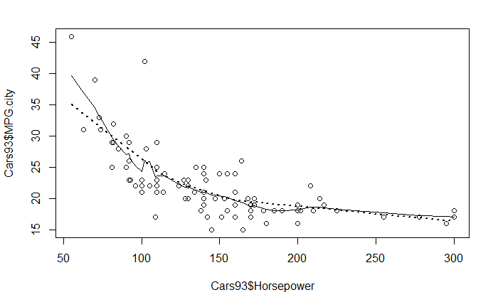

Managing visual complexity Too small - Visual utility loss, too much information on the plots Too large - Not visually appealing

Alt: Multiple plots on the same axis using differential techniques color encoding, legends

How much detail is too much?

`r ## Too much detail, too many plots # Compute the number of plots to be displayed ncol(Cars93)^2`

`[1] 729`

`r # Plot the array of scatterplots plot(Cars93)`

`Error in plot.new() : figure margins too large`

Using the matplot function to create multiple plots on the same plot

Wordcloud package Min freq value = 3 by default, can be changed to 1 for all manufacturers

Creating plot arrays with mfrow argument

Multiple plot arrays - Differences/different views of dataset

Pairs function(sets up two columns)

mfrow - multiple plots layout - multiple plots

plot size pty = s(square), im (Max available space)

Creating multiple plots in the same window

Common Scaling - Is used to set the common limites of each variable. This means that different datasets can be compared easily since juxtaposing datasets on same axis can serve as preemptive measure

Exploring different data graphs plotted on the same axis

Creating plots with layout function() layout - uses matrix to define the plot array

Advanced multiple plotting using layout function

Creating different sized subplots - luxury with layout function - cannot be done using par function

Creating and saving more complex plots

Side effects - Generate plots but no return values barplot() - returns numerical value scatterplots()

symbols() - data points can be customized using this

bg = color

plots can be saved as image files png()

Using color effectively

Different colors for differnt categorical variables Limitations: -Color blind -Redistributed as black and white -Too many colors, too less colors

Sol: Ideally 6 Max 12 No more than 20

Adding color to life ;)

Advanced coloring options

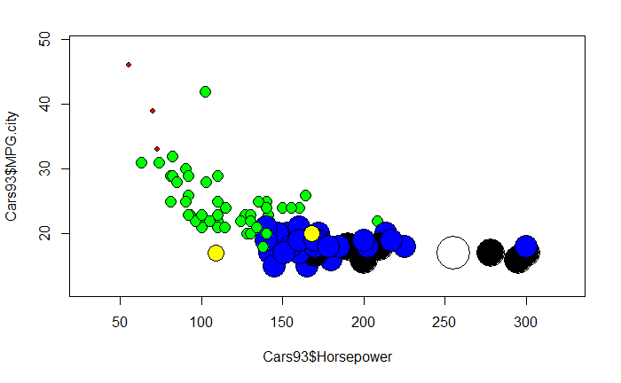

```r
# Iliinsky and Steele color name vector
IScolors <- c("red", "green", "yellow", "blue",
              "black", "white", "pink", "cyan",
              "gray", "orange", "brown", "purple")
# Create the `cylinderLevel` variable
cylinderLevels <- as.numeric(Cars93$Cylinders)
# Create the colored bubbleplot
symbols(Cars93$Horsepower, Cars93$MPG.city,
        circles = cylinderLevels, inches = 0.2,
        bg = IScolors[cylinderLevels])
```

Graphic systems in R 1. Base - Good for exploratory analysis 2. Grid - grid package - greater control over low level graphical details grid-base - hybrid of base and grid 3. Lattice - extension of grid graphics - eg conditional scatterplot 4. ggplot2 - extension of grid graphics - better for high level visualizations stages These are incompatible with each other

Enter ggplot

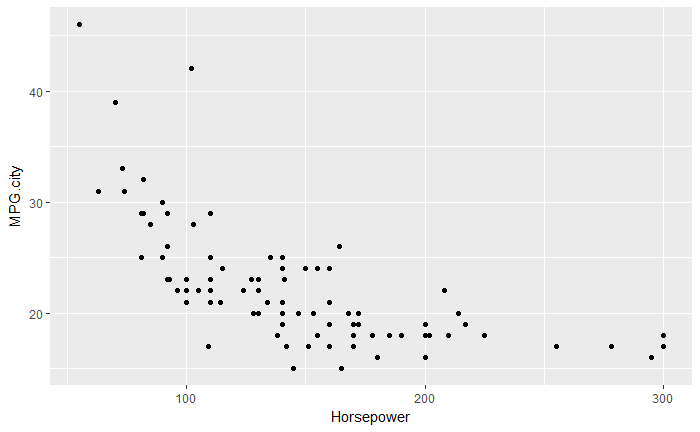

```r
# Load the ggplot2 package
library(ggplot2)
# Create the basic plot (not displayed): basePlot
basePlot <- ggplot(Cars93, aes(x = Horsepower, y = MPG.city))
# Display the basic scatterplot
basePlot +
  geom_point()
```

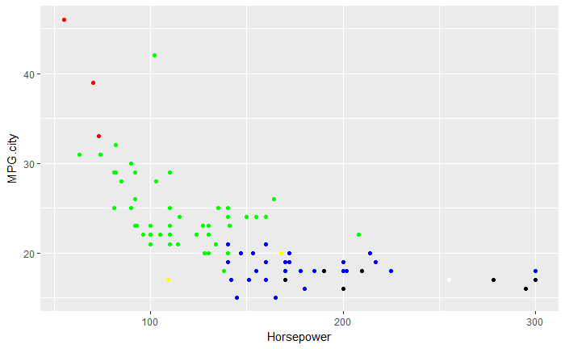

```r
# Color the points by Cylinders value
basePlot +
  geom_point(colour = IScolors[Cars93$Cylinders])
```

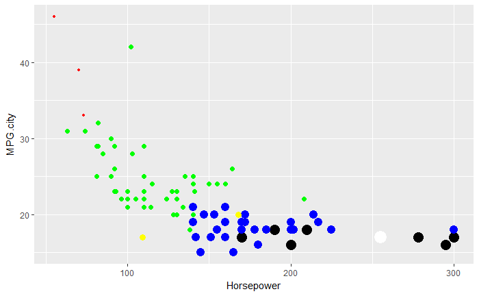

```r
# Make the point sizes also vary with Cylinders value
basePlot +
  geom_point(colour = IScolors[Cars93$Cylinders],
             size = as.numeric(Cars93$Cylinders))
```